# SLE777_AS4_KS

Karmanpreet Sukhija

2025-09-28

# Part 1

**Question 1** First, the gene_expression.tsv file is imported, using the download.file command and read into R as a table. For the read.table command, stringsAsFactors was set to FALSE to ensure strings were imported as strings, not factors (Xie, 2020). This table is assigned to the variable gene_exp. The data is then inspected using the head command which provides the first 6 rows of the table.

```r
URL <- "https://raw.githubusercontent.com/ghazkha/Assessment4/refs/heads/main/gene_expression.tsv"
NAME <- "gene_expression.tsv"
download.file(URL, destfile=NAME)
gene_exp <- read.table("gene_expression.tsv", stringsAsFactors = FALSE, header = TRUE, row.names = 1)
head(gene_exp)
```

```
##                               GTEX.1117F.0226.SM.5GZZ7 GTEX.1117F.0426.SM.5EGHI
## ENSG00000223972.5_DDX11L1                            0                        0
## ENSG00000227232.5_WASH7P                           187                      109
## ENSG00000278267.1_MIR6859-1                          0                        0
## ENSG00000243485.5_MIR1302-2HG                        1                        0
## ENSG00000237613.2_FAM138A                            0                        0
## ENSG00000268020.3_OR4G4P                             0                        1
##                               GTEX.1117F.0526.SM.5EGHJ
## ENSG00000223972.5_DDX11L1                            0
## ENSG00000227232.5_WASH7P                           143
## ENSG00000278267.1_MIR6859-1                          1
## ENSG00000243485.5_MIR1302-2HG                        0
## ENSG00000237613.2_FAM138A                            0
## ENSG00000268020.3_OR4G4P                             0
```

**Question 2** The mean gene count is then calculated by calculating the row mean, as each column is associated with a different sample and each row corresponds to a different gene. Therefore, the rowMeans function is used to calculate the mean gene count for each gene. The mean gene count is then stored under a new column in the table, with the name GENE.MEAN. The mean gene count for the first 6 genes is then observed using the head command.

```r
gene_exp$GENE.MEAN <- rowMeans(gene_exp)
head(gene_exp)
```

```
##                               GTEX.1117F.0226.SM.5GZZ7 GTEX.1117F.0426.SM.5EGHI
## ENSG00000223972.5_DDX11L1                            0                        0
## ENSG00000227232.5_WASH7P                           187                      109
## ENSG00000278267.1_MIR6859-1                          0                        0
## ENSG00000243485.5_MIR1302-2HG                        1                        0
## ENSG00000237613.2_FAM138A                            0                        0
## ENSG00000268020.3_OR4G4P                             0                        1
##                               GTEX.1117F.0526.SM.5EGHJ   GENE.MEAN
## ENSG00000223972.5_DDX11L1                            0   0.0000000
## ENSG00000227232.5_WASH7P                           143 146.3333333
## ENSG00000278267.1_MIR6859-1                          1   0.3333333
## ENSG00000243485.5_MIR1302-2HG                        0   0.3333333
## ENSG00000237613.2_FAM138A                            0   0.0000000
## ENSG00000268020.3_OR4G4P                             0   0.3333333
```

**Question 3** The table is then ordered, based on mean gene count, in descending order. This is conducted using the order command and the now sorted table is stored under the variable sorted_mean_genes. Following from this, the top 10 genes with the highest mean gene count is assessed using the head command, where n=10, to show the first 10 rows.

```r
sorted_mean_genes <- gene_exp[order(gene_exp$GENE.MEAN, decreasing = TRUE),]
head(sorted_mean_genes, n=10)
```

```
##                           GTEX.1117F.0226.SM.5GZZ7 GTEX.1117F.0426.SM.5EGHI
## ENSG00000198804.2_MT-CO1                    267250                  1101779
## ENSG00000198886.2_MT-ND4                    273188                   991891
## ENSG00000198938.2_MT-CO3                    250277                  1041376
## ENSG00000198888.2_MT-ND1                    243853                   772966
## ENSG00000198899.2_MT-ATP6                   141374                   696715
## ENSG00000198727.2_MT-CYB                    127194                   638209
## ENSG00000198763.3_MT-ND2                    159303                   543786
## ENSG00000211445.11_GPX3                     464959                    39396
## ENSG00000198712.1_MT-CO2                    128858                   545360
## ENSG00000156508.17_EEF1A1                   317642                    39573
##                           GTEX.1117F.0526.SM.5EGHJ GENE.MEAN
## ENSG00000198804.2_MT-CO1                    218923  529317.3
## ENSG00000198886.2_MT-ND4                    277628  514235.7
## ENSG00000198938.2_MT-CO3                    223178  504943.7
## ENSG00000198888.2_MT-ND1                    194032  403617.0
## ENSG00000198899.2_MT-ATP6                   151166  329751.7
## ENSG00000198727.2_MT-CYB                    141359  302254.0
## ENSG00000198763.3_MT-ND2                    149564  284217.7
## ENSG00000211445.11_GPX3                     306070  270141.7
## ENSG00000198712.1_MT-CO2                    122816  265678.0
## ENSG00000156508.17_EEF1A1                   339347  232187.3
```

**Question 4** To determine the number of genes that have a mean gene count of less than 10, the data is subsetted using the subset command, and all the genes which have a mean gene count <10 are stored in the variable low_gene_number as a new table. The number of rows is then calculated to compute the number of genes present in this table.

```r
low_gene_number <- subset(gene_exp, GENE.MEAN < 10)
nrow(low_gene_number)
```

```
## [1] 35988
```

**Question 5** The distribution of the mean gene count is then visualised using a histogram. As the data is heavily skewed, a second histogram is also generated, with a limit on the x-axis at 5000 and with more breaks (tubby and zx8754, 2015), to observe where most of the data is distributed and provide a better visualisation of the mean gene expression.

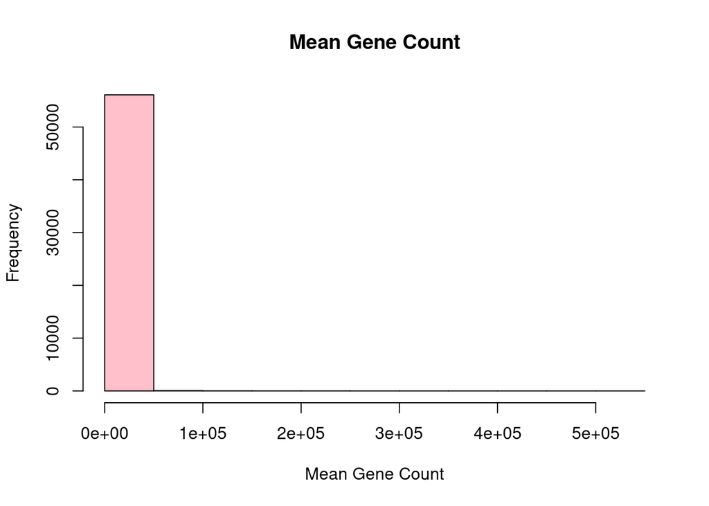

```r
hist(gene_exp$GENE.MEAN,
     xlab = "Mean Gene Count",
     ylab = "Frequency",
     main = "Mean Gene Count",
     col = "pink")
```

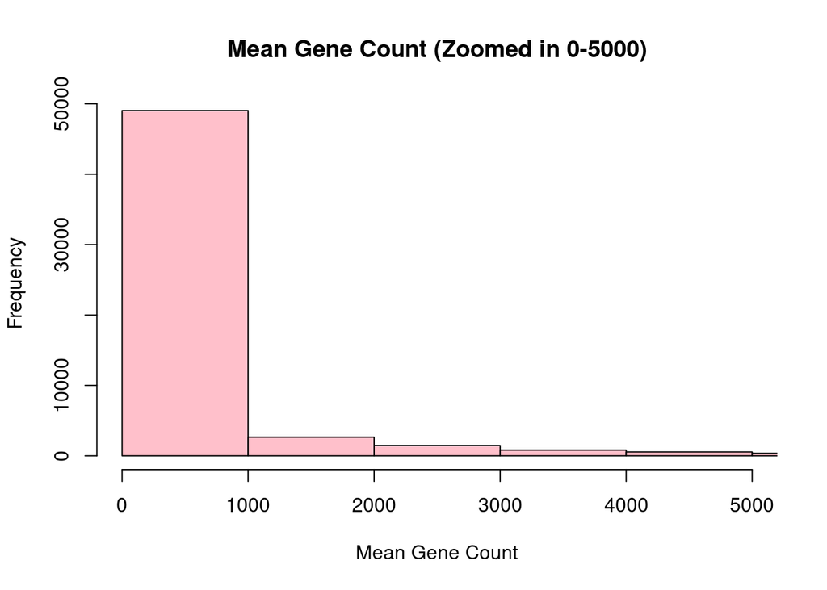

```r
#More 'zoomed in' view of the histogram, as it is heavily skewed.
hist(gene_exp$GENE.MEAN,
     xlab = "Mean Gene Count",
     ylab = "Frequency",
     main = "Mean Gene Count (Zoomed in 0-5000)",
     col = "pink",
     xlim = c(0,5000),
     breaks = 500)
```

**Question 6** Using the download.file command, the growth_data.csv file is imported. The column names are then investigated using the head command, which prints the fist 6 rows of the table.

```r
URL2 = "https://raw.githubusercontent.com/ghazkha/Assessment4/refs/heads/main/growth_data.csv"
NAME2 = "growth_data.csv"
download.file(URL2, destfile = NAME2)
growth_data <- read.table("growth_data.csv", sep = ",", header = TRUE)
head(growth_data)
```

```
##        Site TreeID Circumf_2005_cm Circumf_2010_cm Circumf_2015_cm
## 1 northeast   A012             5.2            10.1            19.9
## 2 southwest   A039             4.9             9.6            18.9
## 3 southwest   A010             3.7             7.3            14.3
## 4 northeast   A087             3.8             6.5            10.9
## 5 southwest   A074             3.8             6.4            10.9
## 6 northeast   A008             5.9            10.0            16.8
##   Circumf_2020_cm
## 1            38.9
## 2            37.0
## 3            28.1
## 4            18.5
## 5            18.4
## 6            28.4
```

**Question 7** The trees at the North-East and South-West sites are subsetted into two different variables. From there, the mean and standard deviations of the tree circumferences are calculated at the start of the study, in 2005, and at the end of the study, in 2020, at each site.

```r
#North-East Site Trees
northeast_trees <- subset(growth_data, Site == "northeast")

#Start of the study
mean(northeast_trees$Circumf_2005_cm)
```

```
## [1] 5.292
```

```r
sd(northeast_trees$Circumf_2005_cm)
```

```
## [1] 0.9140267
```

```r
#End of the study
mean(northeast_trees$Circumf_2020_cm)
```

```
## [1] 54.228
```

```r
sd(northeast_trees$Circumf_2020_cm)
```

```
## [1] 25.22795
```

```r
#--------------------------------------------------------------------#

#South-West Site Trees
southwest_trees <- subset(growth_data, Site == "southwest")

#Start of the study
mean(southwest_trees$Circumf_2005_cm)
```

```
## [1] 4.862
```

```r
sd(southwest_trees$Circumf_2005_cm)
```

```
## [1] 1.147471
```

```r
#End of the study
mean(southwest_trees$Circumf_2020_cm)
```

```
## [1] 45.596
```

```r
sd(southwest_trees$Circumf_2020_cm)
```

```
## [1] 17.87345
```

**Question 8** A boxplot is then generated to visualise the distribution of tree circumference at the start of the study and at the end of the study, at each site to then compare the differences between the sites.

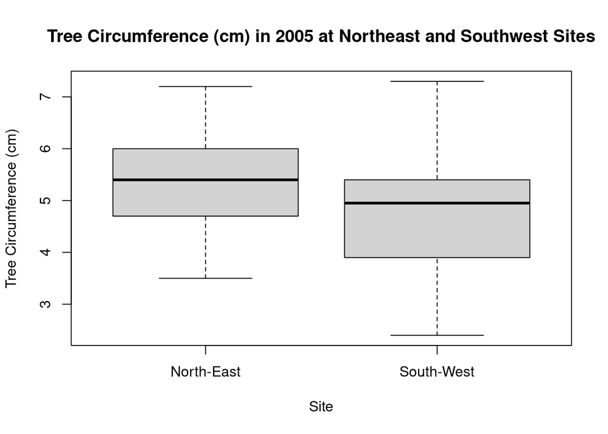

```r
#Boxplot of tree circumference at each site at the start of the study, 2005
boxplot(northeast_trees$Circumf_2005_cm, southwest_trees$Circumf_2005_cm,
        ylab = "Tree Circumference (cm)",
        xlab = "Site",
        main = "Tree Circumference (cm) in 2005 at Northeast and Southwest Sites",
        names = c("North-East", "South-West"))
```

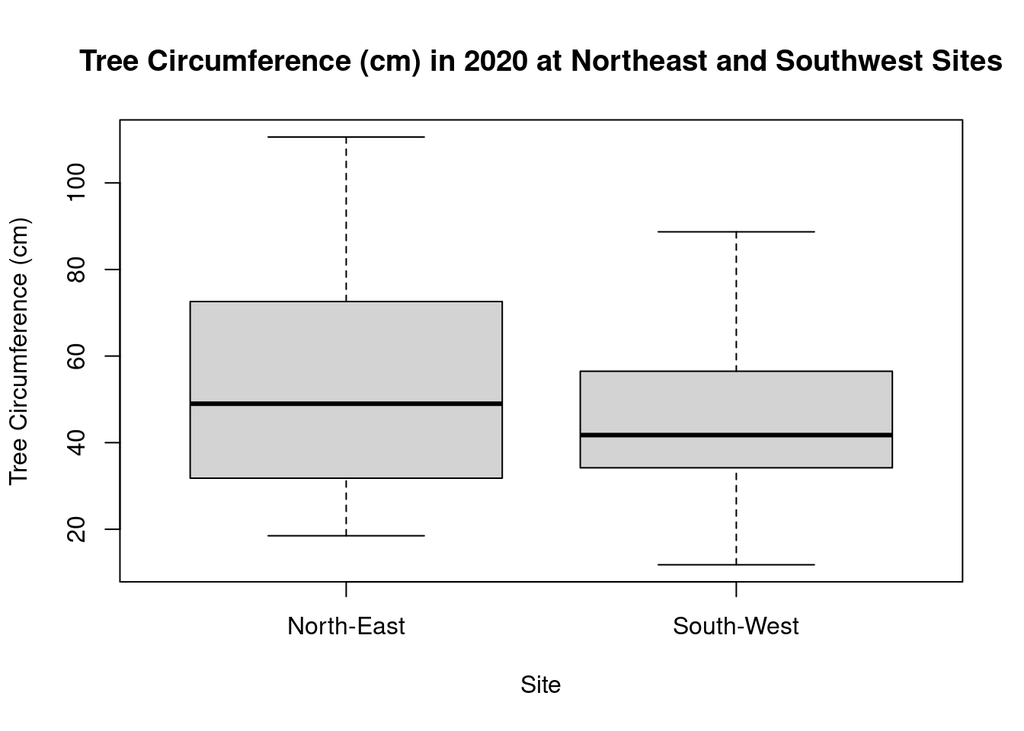

```r
#Boxplot of tree circumference at each site at the end of the study, 2020
boxplot(northeast_trees$Circumf_2020_cm, southwest_trees$Circumf_2020_cm,
        ylab = "Tree Circumference (cm)",
        xlab = "Site",
        main = "Tree Circumference (cm) in 2020 at Northeast and Southwest Sites",
        names = c("North-East", "South-West"))
```

**Question 9** The mean growth over the last 10 years (2010 - 2020) is calculated through the subtraction of the tree circumference in 2010 from the tree circumference in 2020. The mean differences between the two timepoints is then calculated using the mean function, for both sites.

```r
#Mean 10 year growth for North-East site
mean(northeast_trees$Circumf_2020_cm - northeast_trees$Circumf_2010_cm)
```

```
## [1] 42.94
```

```r
#Mean 10 year growth for South-West site
mean(southwest_trees$Circumf_2020_cm - southwest_trees$Circumf_2010_cm)
```

```
## [1] 35.49
```

**Question 10** Welch’s t-test is then used to determine whether the 10 year growth at the North-East site is statitsically significantly different to the 10 year growth at the South-West site. This is performed by first generating new columns in the tables to store the values of the 10 year growth of tree circumferences at each site.

To determine whether to perform a Students t-test of Welch’s t-test, an F-test is conducted to test for equal variance (O’Brien, 2023).

```r
#10 year growth at the North-East site
northeast_trees$Tenyear_growth <- northeast_trees$Circumf_2020_cm - northeast_trees$Circumf_2010_cm

#10 year growth at the South-West site
southwest_trees$Tenyear_growth <- southwest_trees$Circumf_2020_cm - southwest_trees$Circumf_2010_cm

#Determine the appropriate t-test, Welch's vs Students, via F-test
var.test(northeast_trees$Tenyear_growth, southwest_trees$Tenyear_growth)
```

```
##
##  F test to compare two variances
##
## data:  northeast_trees$Tenyear_growth and southwest_trees$Tenyear_growth
## F = 2.0189, num df = 49, denom df = 49, p-value = 0.01543
## alternative hypothesis: true ratio of variances is not equal to 1
## 95 percent confidence interval:
##  1.145675 3.557673
## sample estimates:
## ratio of variances
##           2.018895
```

As the F-test generates a statistically significant p-value, this means that the two variables do not have equal variance and thus Welch’s t-test is most appropriate to use. These variables are then used to conduct Welch’s t-test, which does not assume equal standard deviations between the two variables.

```r
#Welch's t-test
t.test(northeast_trees$Tenyear_growth, southwest_trees$Tenyear_growth)
```

```
##
##  Welch Two Sample t-test
##
## data:  northeast_trees$Tenyear_growth and southwest_trees$Tenyear_growth
## t = 1.8882, df = 87.978, p-value = 0.06229
## alternative hypothesis: true difference in means is not equal to 0
## 95 percent confidence interval:
##  -0.3909251 15.2909251
## sample estimates:
## mean of x mean of y
##     42.94     35.49
```

# Part 2

**Question 1** First, the packages seqinr and R.utils are loaded.

```r
suppressPackageStartupMessages({
  library("seqinr")
  library("R.utils")
})
```

The download.file command is used to download the FASTA files of the coding sequences of E.coli and S.thermophilus. The gunzip command is then used to unzip the files. Following this, the seqinr package is used to read-in the FASTA files into a FASTA file format.

```r
#Downloading and reading in the E.coli coding sequence
URL_e.coli="http://ftp.ensemblgenomes.org/pub/bacteria/release-53/fasta/bacteria_0_collection/escherichia_coli_str_k_12_substr_mg1655_gca_000005845/cds/Escherichia_coli_str_k_12_substr_mg1655_gca_000005845.ASM584v2.cds.all.fa.gz"
download.file(URL_e.coli, destfile = "ecoli_cds.fa.gz")
#gunzip("ecoli_cds.fa.gz")

cds_ecoli <- seqinr::read.fasta("ecoli_cds.fa")

#Downloading and reading in the S.thermophilus coding sequence
URL_s.thermo = "https://ftp.ensemblgenomes.ebi.ac.uk/pub/bacteria/release-62/fasta/bacteria_121_collection/streptococcus_thermophilus_cag_236_gca_000434755/cds/Streptococcus_thermophilus_cag_236_gca_000434755.MGS236.cds.all.fa.gz"
download.file(URL_s.thermo, destfile = "sthermo_cds.fa.gz")
#gunzip("sthermo_cds.fa.gz")

cds_sthermo <- seqinr::read.fasta("sthermo_cds.fa")

list.files()
```

```
##  [1] "AS4.Rproj"            "codonuse_ecoli.csv"   "codonuse_sthermo.csv"
##  [4] "ecoli_cds.fa"         "ecoli_cds.fa.gz"      "gene_expression.tsv"
##  [7] "growth_data.csv"      "LICENSE"              "README.md"
## [10] "SLE777_AS4_KS_files"  "SLE777_AS4_KS.html"   "SLE777_AS4_KS.Rmd"
## [13] "sthermo_cds.fa"       "sthermo_cds.fa.gz"
```

The calculate the number of coding sequences present in each organism, the length command is used which returns the number of coding sequences present. The head command is also used to get a feel of the data and ensure it is in the correct format.

```r
#Number of coding sequences present in E.coli and summary of the imported data
length(cds_ecoli)
```

```
## [1] 4239
```

```r
head(summary(cds_ecoli))
```

```
##          Length Class       Mode
## AAC73112   66   SeqFastadna character
## AAC73113 2463   SeqFastadna character
## AAC73114  933   SeqFastadna character
## AAC73115 1287   SeqFastadna character
## AAC73116  297   SeqFastadna character
## AAC73117  777   SeqFastadna character
```

```r
#Number of coding sequences present in S.thermophilus and summary of the imported data
length(cds_sthermo)
```

```
## [1] 1741
```

```r
head(summary(cds_sthermo))
```

```
##                      Length Class       Mode
## ENSB:zG_Pj-uGQ5VDFKI  534   SeqFastadna character
## ENSB:b8eBE9iYnXlvd8C  558   SeqFastadna character
## ENSB:DFnvE03Og6aJLcN  561   SeqFastadna character
## ENSB:syxHZ_Syik9x0rz 1503   SeqFastadna character
## ENSB:WEw7YehRxm7WlXa  504   SeqFastadna character
## ENSB:1ucMnDaoqjHJ9VA  108   SeqFastadna character
```

**Question 2** To compute the number of base pairs present in the total coding sequence, the length of all coding sequences are summed by storing the lengths of each coding sequence under the len_ecoli and len_sthermo variables. Once these variables have been summed, the output results in the total number of base pairs present in the coding sequence of each organism.

```r
#Total number of base pairs present in the coding sequence of E.coli
len_ecoli <- as.numeric(summary(cds_ecoli)[,1])
sum(len_ecoli)
```

```
## [1] 3978528
```

```r
#Total number of base pairs present in the coding sequence of S.thermophilus
len_sthermo <- as.numeric(summary(cds_sthermo)[,1])
sum(len_sthermo)
```

```
## [1] 1374033
```

**Question 3** To compare the distribution of coding sequence length, a boxplot is used to visualise this parameter. Following this, the mean and median functions are used to calculate the mean and median coding sequence length in each organism.

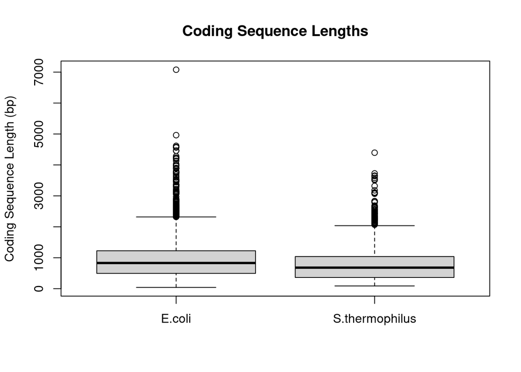

```r
#Visualisation of distribution of coding sequence length in each organism
boxplot(len_ecoli, len_sthermo,
        ylab = "Coding Sequence Length (bp)",
        main = "Coding Sequence Lengths",
        names = c("E.coli", "S.thermophilus"))
```

```r
#Calculation of mean and median coding sequence length in E.coli
mean(len_ecoli)
```

```
## [1] 938.5534
```

```r
mean(len_sthermo)
```

```
## [1] 789.2206
```

```r
#Calculation of mean and median coding sequence length in S.thermophilus
median(len_ecoli)
```

```
## [1] 831
```

```r
median(len_sthermo)
```

```
## [1] 681
```

**Question 4** As the current data is present as a dataframe, in order to allow for the DNA composition to be calculated, the coding sequence is unlisted so that it is now a long string of nucleotides. This allows for the number of nucleotides to be present and thus the nucleotide composition of the total coding sequence to be visualised, using a barplot, for each organism.

```r
#Unlisting of E.coli coding sequence
dna_ecoli <- unlist(cds_ecoli)
#Counting the total number of each nucleotide present in the total coding sequence of E.coli
dna_comp_ecoli <- count(dna_ecoli,1)
dna_comp_ecoli
```

```
##
##       a       c       g       t
##  955768  977594 1088501  956665
```

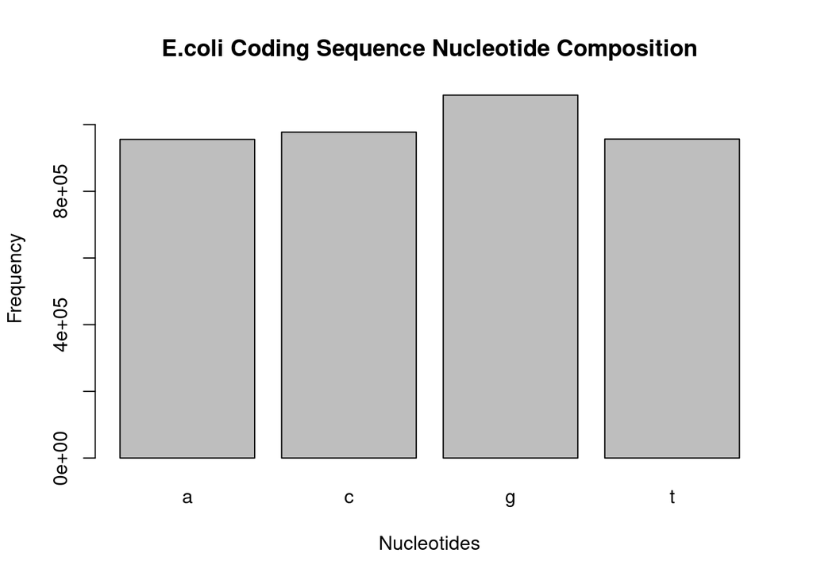

```r
#Visualisation of nucleotide composition of total coding sequence of E.coli
barplot(dna_comp_ecoli,
        xlab = "Nucleotides",
        ylab = "Frequency",
        main = "E.coli Coding Sequence Nucleotide Composition")
```

```r
#Unlisting of S.thermophilus coding sequence
dna_sthermo <- unlist(cds_sthermo)
#Counting the total number of each nucleotide present in the total coding sequence of S.thermophilus
dna_comp_sthermo <- count(dna_sthermo,1)
dna_comp_sthermo
```

```
##
##      a      c      g      t
## 409870 254415 296288 413120
```

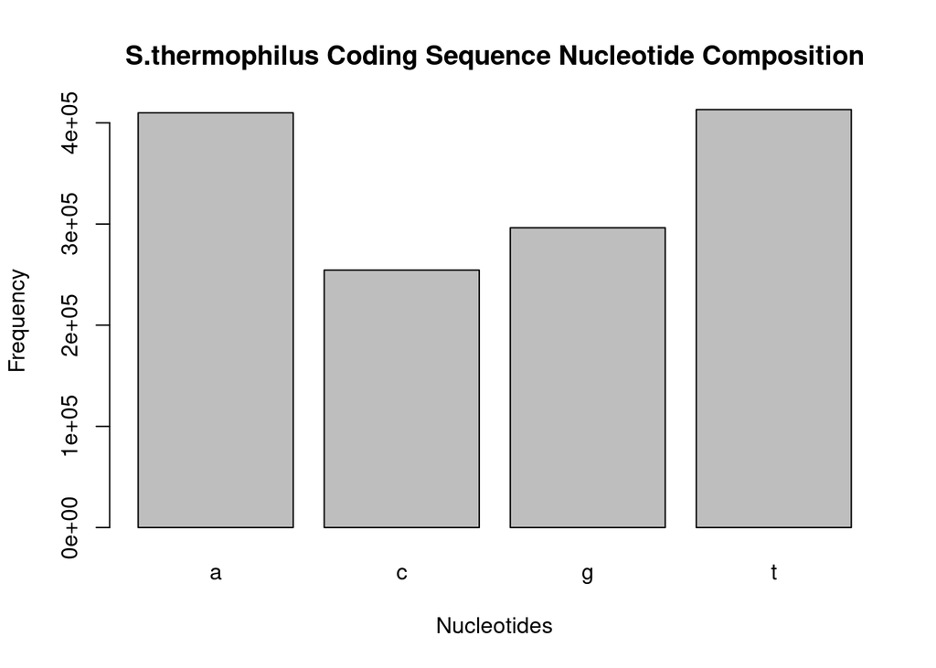

```r
#Visualisation of nucleotide composition of total coding sequence of S.thermophilus
barplot(dna_comp_sthermo,
        xlab = "Nucleotides",
        ylab = "Frequency",
        main = "S.thermophilus Coding Sequence Nucleotide Composition")
```

The same is then done for the total protein sequence, which is first translated using the seqinr package. Following this, the alphabet which corresponds to the amino acids present in E.coli and S.thermophilus is stored and used to count the number of each amino acid present in the coding sequence of each organism. The amino acid composition of the total coding sequence of each organism is then visualised using a barplot.

```r
#Translation of full DNA coding sequence of E.coli to amino acid coding sequence
fullprotein_ecoli <- unlist(lapply(cds_ecoli, translate))

#All unique amino acids present within E.coli are stored, expect for * which corresponds to a stop codon.
aa <- unique(fullprotein_ecoli)
aa <- aa[aa != "*"]

#The number of amino acids present in the coding sequence of E.coli is counted
protein_comp_ecoli <- count(fullprotein_ecoli,wordsize=1,alphabet=aa)
protein_comp_ecoli
```

```
##
##      A      C      D      E      F      G      H      I      K      L      M
## 126127  15376  67796  76338  51561  97246  29995  79511  58113 141731  37007
##      N      P      Q      R      S      T      V      W      Y
##  51503  58700  58799  73111  76412  71025  93989  20196  37401
```

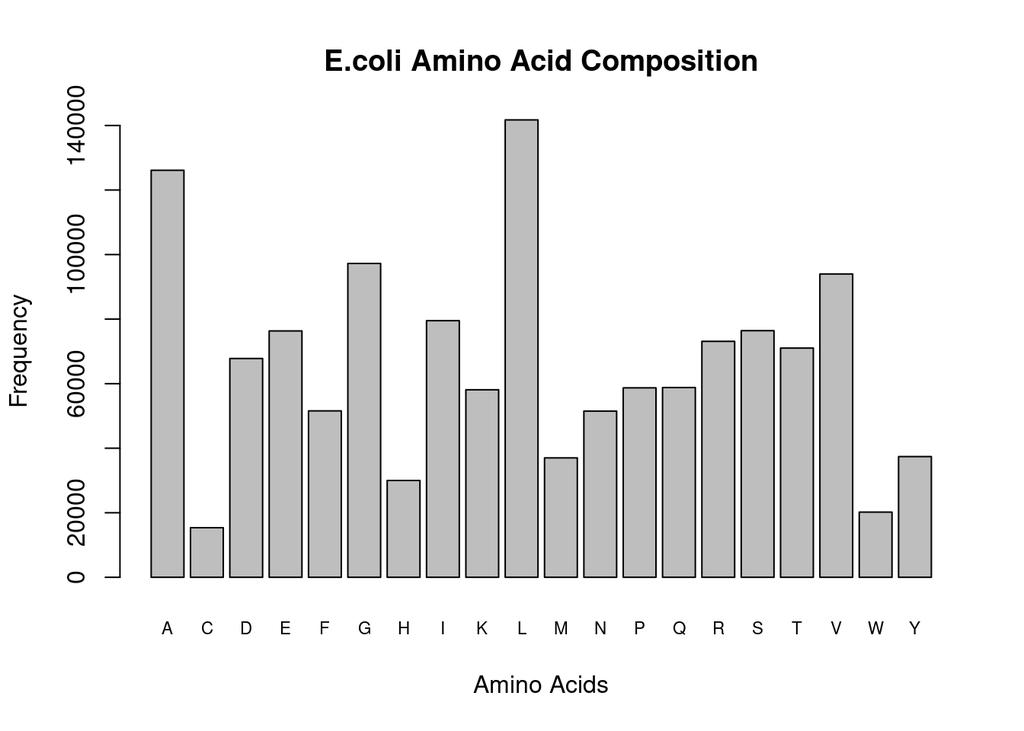

```r
#The amino acid composition of the total coding sequence of E.coli is visualised using a barplot, with the x-axis labels being shrunk to include all amino acids on the axis
barplot(protein_comp_ecoli,
        xlab = "Amino Acids",
        ylab = "Frequency",
        main = "E.coli Amino Acid Composition",
        cex.names = 0.7)
```

```r
#######

#Translation of full DNA coding sequence of S.thermophilus to amino acid coding sequence
fullprotein_sthermo <- unlist(lapply(cds_sthermo, translate))

#The number of amino acids present in the coding sequence of S.thermophilus is counted, using the same alphabet as used with E.coli
protein_comp_sthermo <- count(fullprotein_sthermo,wordsize=1,alphabet=aa)
protein_comp_sthermo
```

```
##
##     A     C     D     E     F     G     H     I     K     L     M     N     P
## 34432  2539 26825 31175 20924 30325  8650 33820 31011 45628 11326 20751 14936
##     Q     R     S     T     V     W     Y
## 17123 18555 28504 26003 32816  3814 16992
```

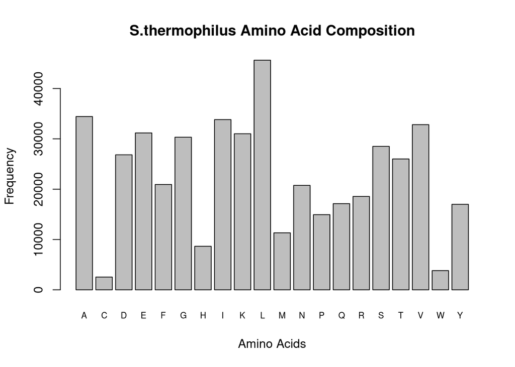

```r
#The amino acid composition of the total coding sequence of S.thermophilus is visualised using a barplot, with the x-axis labels being shrunk to include all amino acids on the axis
barplot(protein_comp_sthermo,
        xlab = "Amino Acids",
        ylab = "Frequency",
        main = "S.thermophilus Amino Acid Composition",
        cex.names = 0.7)
```

**Question 5** Using the seqinr package, the codon usage indices are calculated. The focus here is on the Relative Synonymous Codon Usage (RSCU) values, which corresponds to how preferred a certain codon is for a particular amino acid, compared to other codons which are used to code for that amino acid. The RSCU value is how codon usage bias is calculated within this assessment. The RSCU values are also visualised for each codon.

```r
#Calculation of codon usage indices for E.coli
codonuse_ecoli <- uco(unlist(cds_ecoli), index = "rscu", as.data.frame = TRUE)
codonuse_ecoli
```

```
##      AA codon   eff         freq      RSCU
## aaa Lys   aaa 44592 0.0336244963 1.5346652
## aac Asn   aac 28454 0.0214556741 1.1049453
## aag Lys   aag 13521 0.0101954793 0.4653348
## aat Asn   aat 23049 0.0173800461 0.8950547
## aca Thr   aca  9116 0.0068738991 0.5133967
## acc Thr   acc 31139 0.0234802922 1.7536924
## acg Thr   acg 19081 0.0143879847 1.0746075
## act Thr   act 11689 0.0088140639 0.6583034
## aga Arg   aga  2573 0.0019401648 0.2111584
## agc Ser   agc 21291 0.0160544302 1.6718055
## agg Arg   agg  1420 0.0010707478 0.1165351
## agt Ser   agt 11487 0.0086617463 0.9019787
## ata Ile   ata  5486 0.0041367058 0.2069902
## atc Ile   atc 33524 0.0252786960 1.2648816
## atg Met   atg 37007 0.0279050443 1.0000000
## att Ile   att 40501 0.0305396870 1.5281282
## caa Gln   caa 20402 0.0153840818 0.6939574
## cac His   cac 12890 0.0097196752 0.8594766
## cag Gln   cag 38397 0.0289531706 1.3060426
## cat His   cat 17105 0.0128979864 1.1405234
## cca Pro   cca 11163 0.0084174348 0.7606814
## ccc Pro   ccc  7238 0.0054577975 0.4932198
## ccg Pro   ccg 31074 0.0234312791 2.1174787
## cct Pro   cct  9225 0.0069560903 0.6286201
## cga Arg   cga  4619 0.0034829465 0.3790674
## cgc Arg   cgc 29441 0.0221999192 2.4161344
## cgg Arg   cgg  7079 0.0053379039 0.5809523
## cgt Arg   cgt 27979 0.0210975014 2.2961524
## cta Leu   cta  5149 0.0038825918 0.2179763
## ctc Leu   ctc 14811 0.0111682009 0.6270047
## ctg Leu   ctg 70714 0.0533217311 2.9935864
## ctt Leu   ctt 14586 0.0109985402 0.6174796
## gaa Glu   gaa 52679 0.0397224803 1.3801514
## gac Asp   gac 25347 0.0191128478 0.7477432
## gag Glu   gag 23659 0.0178400152 0.6198486
## gat Asp   gat 42449 0.0320085720 1.2522568
## gca Ala   gca 26743 0.0201654984 0.8481293
## gcc Ala   gcc 34117 0.0257258463 1.0819888
## gcg Ala   gcg 45082 0.0339939797 1.4297335
```

[output cut: 10 more lines]

```
## tac Tyr   tac 16160 0.0121854113 0.8641480
## tag Stp   tag   294 0.0002216900 0.2080679
## tat Tyr   tat 21241 0.0160167278 1.1358520
## tca Ser   tca  9303 0.0070149060 0.7304874
## tcc Ser   tcc 11390 0.0085886036 0.8943621
## tcg Ser   tcg 11830 0.0089203846 0.9289117
## tct Ser   tct 11111 0.0083782243 0.8724546
## tga Stp   tga  1219 0.0009191842 0.8627035
## tgc Cys   tgc  8574 0.0064652052 1.1152445
## tgg Trp   tgg 20196 0.0152287479 1.0000000
## tgt Cys   tgt  6802 0.0051290326 0.8847555
## tta Leu   tta 18323 0.0138164165 0.7756807
## ttc Phe   ttc 21974 0.0165694448 0.8523496
## ttg Leu   ttg 18148 0.0136844582 0.7682723
## ttt Phe   ttt 29587 0.0223100101 1.1476504
```

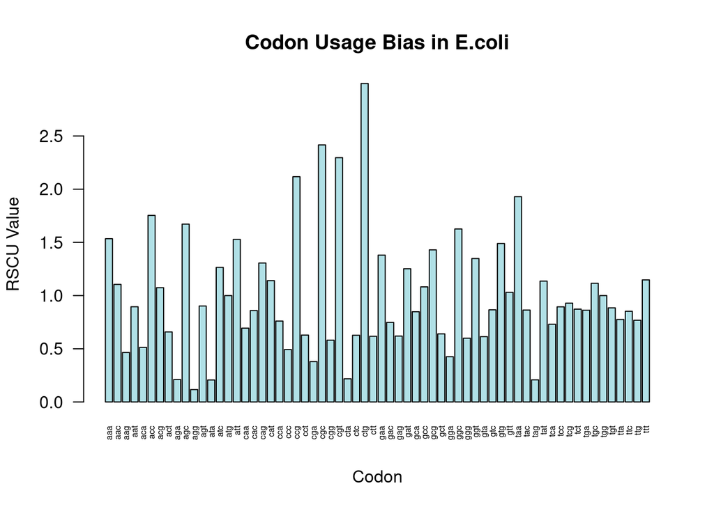

```r
#Visualisation of RSCU values of each codon present in the coding sequence of E.coli
barplot(codonuse_ecoli$RSCU,
        names.arg = codonuse_ecoli$codon,
        las = 2,
        xlab = "Codon",
        ylab = "RSCU Value",
        main = "Codon Usage Bias in E.coli",
        col = "powderblue",
        cex.names = 0.5)
```

```r
#Calculation of codon usage indices for S.thermophilus
codonuse_sthermo <- uco(unlist(cds_sthermo), index = "rscu", as.data.frame = TRUE)
codonuse_sthermo
```

```
##      AA codon   eff         freq      RSCU
## aaa Lys   aaa 19377 0.0423068442 1.2496856
## aac Asn   aac  6912 0.0150913406 0.6661848
## aag Lys   aag 11634 0.0254011367 0.7503144
## aat Asn   aat 13839 0.0302154315 1.3338152
## aca Thr   aca  8877 0.0193816306 1.3655347
## acc Thr   acc  4836 0.0105586984 0.7439142
## acg Thr   acg  2971 0.0064867438 0.4570242
## act Thr   act  9319 0.0203466729 1.4335269
## aga Arg   aga  2181 0.0047618944 0.7052546
## agc Ser   agc  3050 0.0066592287 0.6420152
## agg Arg   agg   909 0.0019846685 0.2939369
## agt Ser   agt  6163 0.0134560087 1.2972916
## ata Ile   ata  2906 0.0063448258 0.2577765
## atc Ile   atc 10885 0.0237658048 0.9655529
## atg Met   atg 11326 0.0247286637 1.0000000
## att Ile   att 20029 0.0437303908 1.7766706
## caa Gln   caa 11873 0.0259229582 1.3867897
## cac His   cac  3428 0.0074845364 0.7926012
## cag Gln   cag  5250 0.0114626068 0.6132103
## cat His   cat  5222 0.0114014729 1.2073988
## cca Pro   cca  7047 0.0153860933 1.8872523
## ccc Pro   ccc  1106 0.0024147892 0.2961971
## ccg Pro   ccg  1124 0.0024540895 0.3010177
## cct Pro   cct  5659 0.0123555984 1.5155329
## cga Arg   cga  1844 0.0040261042 0.5962813
## cgc Arg   cgc  2314 0.0050522804 0.7482619
## cgg Arg   cgg   473 0.0010327263 0.1529507
## cgt Arg   cgt 10834 0.0236544537 3.5033145
## cta Leu   cta  4800 0.0104800976 0.6311914
## ctc Leu   ctc  5227 0.0114123897 0.6873411
## ctg Leu   ctg  2790 0.0060915568 0.3668800
## ctt Leu   ctt 12960 0.0282962636 1.7042167
## gaa Glu   gaa 21340 0.0465927674 1.3690457
## gac Asp   gac  7935 0.0173249114 0.5916123
## gag Glu   gag  9835 0.0214732834 0.6309543
## gat Asp   gat 18890 0.0412435509 1.4083877
## gca Ala   gca  8764 0.0191349116 1.0181227
## gcc Ala   gcc  6715 0.0146612199 0.7800883
## gcg Ala   gcg  3168 0.0069168644 0.3680297
```

[output cut: 10 more lines]

```
## tac Tyr   tac  5819 0.0127049350 0.6849105
## tag Stp   tag   387 0.0008449579 0.6668581
## tat Tyr   tat 11173 0.0243946106 1.3150895
## tca Ser   tca  8308 0.0181393023 1.7488072
## tcc Ser   tcc  1844 0.0040261042 0.3881560
## tcg Ser   tcg  1570 0.0034278653 0.3304799
## tct Ser   tct  7569 0.0165258040 1.5932501
## tga Stp   tga   263 0.0005742220 0.4531878
## tgc Cys   tgc   601 0.0013121956 0.4734147
## tgg Trp   tgg  3814 0.0083273109 1.0000000
## tgt Cys   tgt  1938 0.0042313394 1.5265853
## tta Leu   tta  7910 0.0172703276 1.0401508
## ttc Phe   ttc  7170 0.0156546458 0.6853374
## ttg Leu   ttg 11941 0.0260714262 1.5702200
## ttt Phe   ttt 13754 0.0300298464 1.3146626
```

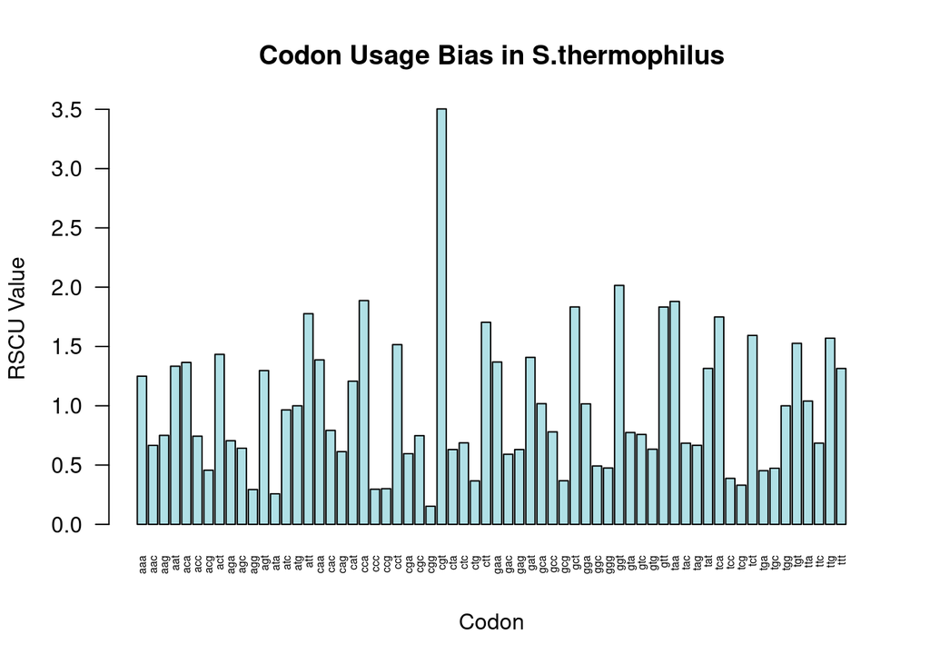

```r
#Visualisation of RSCU values of each codon present in the coding sequence of S.thermophilus
barplot(codonuse_sthermo$RSCU,
        names.arg = codonuse_sthermo$codon,
        las = 2,
        xlab = "Codon",
        ylab = "RSCU Value",
        main = "Codon Usage Bias in S.thermophilus",
        col = "powderblue",
        cex.names = 0.5)
```

**Question 6** To compute the most under- and over-represented k-mers of length 3-5, the count command is used to count characters of length 3-5, using the alphabet previously described when looking at the amino acid composition of the coding sequence of each organism. The k-mer counts are then sorted in ascending order to view the top 10 most under- and over-represented sequences. Following this, the sorted k-mer counts are visualised using the barplot function to highlight the varying frequency of each k-mer.

```r
#Computation of k-mers of length 3 in E.coli
ecoli_counts3 <- count(fullprotein_ecoli, wordsize = 3, alphabet = aa)
#Sorting k-mer list in ascending order
sorted_ecoli_counts3 <- ecoli_counts3[order(ecoli_counts3)]
#Returning the top 10 most under- and over-represented k-mers of length 3 in E.coli
head(sorted_ecoli_counts3, n=10)
```

```
##
## CMY MWC WMC CMC CMW WCM WWC CHW CWW MCM
##   1   1   1   2   2   2   2   3   3   3
```

```r
tail(sorted_ecoli_counts3, n=10)
```

```
##
##  TLL  LAG  AAA  LAL  AAL  LLL  LAA  ALA  ALL  LLA
## 1102 1178 1338 1536 1594 1594 1601 1740 1744 1817
```

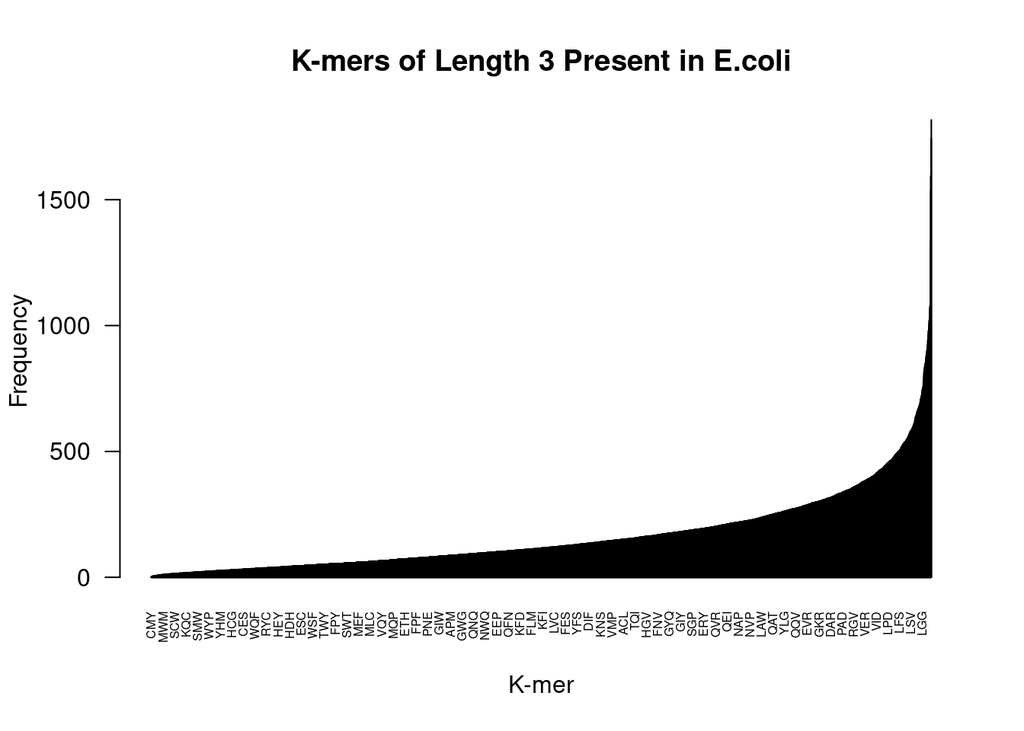

```r
#Visualisation of sorted k-mer count as a barplot
barplot(sorted_ecoli_counts3,
        las = 2,
        xlab = "K-mer",
        ylab = "Frequency",
        main = "K-mers of Length 3 Present in E.coli",
        cex.names = 0.5)
```

```r
#The above is repeated for k-mers of length 4 and 5

ecoli_counts4 <- count(fullprotein_ecoli, wordsize = 4, alphabet = aa)
sorted_ecoli_counts4 <- ecoli_counts4[order(ecoli_counts4)]
head(sorted_ecoli_counts4, n=10)
```

```
##
## ACAM ACCF ACCH ACCI ACCK ACCM ACCQ ACCW ACEW ACFP
##    0    0    0    0    0    0    0    0    0    0
```

```r
tail(sorted_ecoli_counts4, n=10)
```

```
##
## ALLA LALL LALA LLLA LLAA AALA LLLL LLAL ALAA LAAL
##  193  195  196  197  206  207  209  215  233  234
```

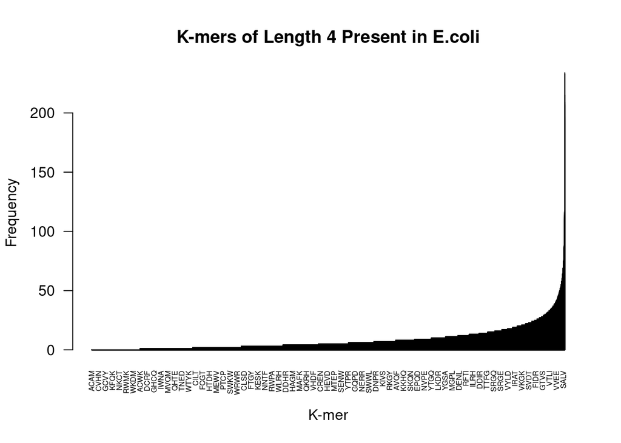

```r
barplot(sorted_ecoli_counts4,
        las = 2,
        xlab = "K-mer",
        ylab = "Frequency",
        main = "K-mers of Length 4 Present in E.coli",
        cex.names = 0.5)
```

```r
ecoli_counts5 <- count(fullprotein_ecoli, wordsize = 5, alphabet = aa)
sorted_ecoli_counts5 <- ecoli_counts5[order(ecoli_counts5)]
head(sorted_ecoli_counts5, n=10)
```

```
##
## AAAAC AAAAW AAACC AAACH AAACI AAACK AAACM AAACN AAACP AAACS
##     0     0     0     0     0     0     0     0     0     0
```

```r
tail(sorted_ecoli_counts5, n=10)
```

```
##
## LDEPT LAAAL LLLAL LLLLL LLLDE AALAA LLAAL SGSGK GSGKS GKSTL
##    33    34    34    34    35    37    37    37    42    58
```

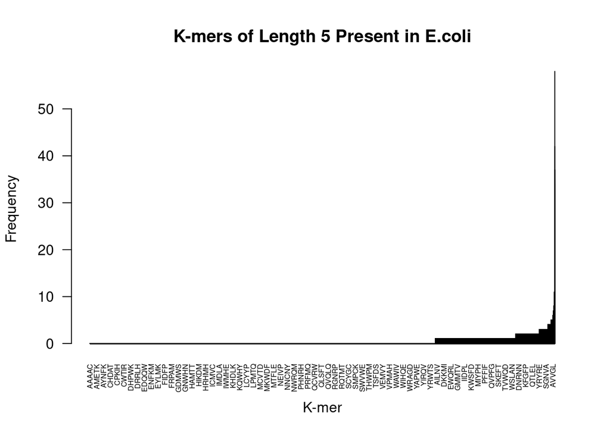

```r
barplot(sorted_ecoli_counts5,
        las = 2,
        xlab = "K-mer",
        ylab = "Frequency",
        main = "K-mers of Length 5 Present in E.coli",
        cex.names = 0.5)
```

```r
##############################################

#k-mers of length 3-5 are computed for S.thermophilus, same as what was done for E.coli

sthermo_counts3 <- count(fullprotein_sthermo, wordsize = 3, alphabet = aa)
sorted_sthermo_counts3 <- sthermo_counts3[order(sthermo_counts3)]
head(sorted_sthermo_counts3, n=10)
```

```
##
## CAW CCA CCE CCI CCM CCP CFC CHC CHM CHW
##   0   0   0   0   0   0   0   0   0   0
```

```r
tail(sorted_sthermo_counts3, n=10)
```

```
##
## LLE LLS ALL KEL LAL ALA EEL LLA LGL LLL
## 335 339 340 342 343 352 360 366 378 403
```

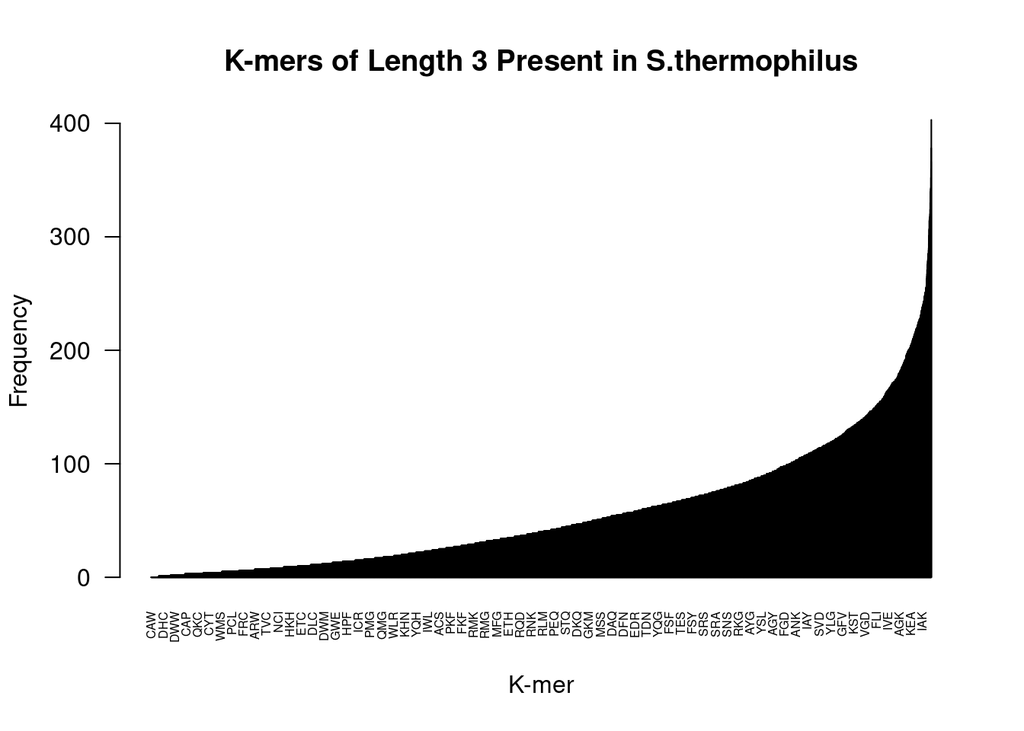

```r
barplot(sorted_sthermo_counts3,
        las = 2,
        xlab = "K-mer",
        ylab = "Frequency",
        main = "K-mers of Length 3 Present in S.thermophilus",
        cex.names = 0.5)
```

```r
sthermo_counts4 <- count(fullprotein_sthermo, wordsize = 4, alphabet = aa)
sorted_sthermo_counts4 <- sthermo_counts4[order(sthermo_counts4)]
head(sorted_sthermo_counts4, n=10)
```

```
##
## AACC AACH AACL AACM AACN AACP AACR AACT AACV AACW
##    0    0    0    0    0    0    0    0    0    0
```

```r
tail(sorted_sthermo_counts4, n=10)
```

```
##
## LADL LLLL LEKL LGLL LLGL SSSS LEEL GSGK LSGG GKST
##   46   47   48   48   48   50   52   54   60   64
```

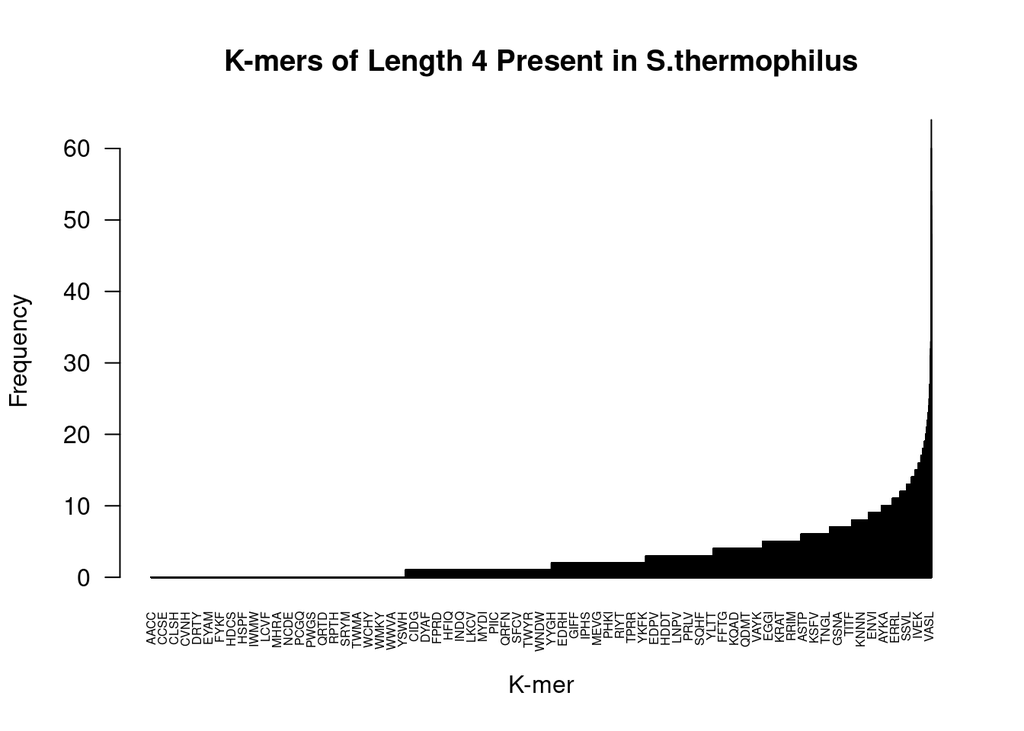

```r
barplot(sorted_sthermo_counts4,
        las = 2,
        xlab = "K-mer",
        ylab = "Frequency",
        main = "K-mers of Length 4 Present in S.thermophilus",
        cex.names = 0.5)
```

```r
sthermo_counts5 <- count(fullprotein_sthermo, wordsize = 5, alphabet = aa)
sorted_sthermo_counts5 <- sthermo_counts5[order(sthermo_counts5)]
head(sorted_sthermo_counts5, n=10)
```

```
##
## AAAAH AAAAL AAAAN AAAAP AAAAS AAAAT AAAAV AAAAW AAACA AAACC
##     0     0     0     0     0     0     0     0     0     0
```

```r
tail(sorted_sthermo_counts5, n=10)
```

```
##
## GQKQR GSGKT AGKST SGGQK SGSGK SGKST GSGKS SSSSS LSGGQ GKSTL
##    17    17    18    18    18    21    24    24    29    33
```

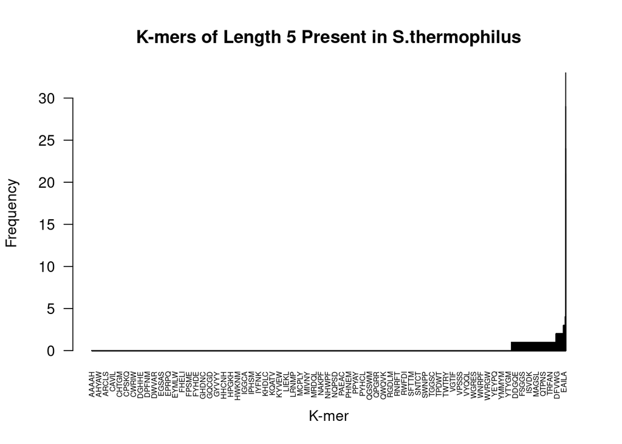

```r
barplot(sorted_sthermo_counts5,
        las = 2,
        xlab = "K-mer",
        ylab = "Frequency",
        main = "K-mers of Length 5 Present in S.thermophilus",
        cex.names = 0.5)
```

# References

Advanced R barplot customization [Online]. Available: https://r-graph-gallery.com/210-custom-barplot-layout.html [Accessed Oct 2025]. Chapter 11 Histogram | Basic R Guide for NSC Statistics [Online]. Available: https://bookdown.org/dli/rguide/histogram.html [Accessed Oct 2025]. O’BRIEN, K. 2023. Testing for Equality of Variance [Online]. Available: https://rpubs.com/DragonflyStats/Variance-Test [Accessed Oct 2025]. TUBBY & ZX8754. 2015. Change scale of histogram in R [Online]. stack overflow. Available: https://stackoverflow.com/questions/30378955/change-scale-of-histogram-in-r [Accessed Oct 2025]. WHV20 & ISSAC. 2015. names on the x-axis of barplot in R? [Online]. stack overflow. Available: https://stackoverflow.com/questions/28416992/names-on-the-x-axis-of-barplot-in-r [Accessed Oct 2025]. XIE, Y. 2020. stringsAsFactors. Available from: https://blog.r-project.org/2020/02/16/stringsasfactors/ [Accessed Oct 2025].